# Characterizing cemented sandstones with physics-based and machine learning approaches

Frank Male

06 March 2020

## Introduction

Sandstones one of the most common types of reservoir rocks. Let’s see if we can explain their permeability.

## Narrative

The most well-known physics-based approach to estimating permeability was developed by Kozeny (1927) and later modified by Carman (1937). In its modern form, the equation is written as
$$\begin{equation}
k = \frac{\phi^3}{2\tau(1-\phi)^2 a^2},
\end{equation}$$
which, for simplicity, we’re going to recast as
$$\begin{equation}
k = \frac{\phi_{CK}}{2\tau a^2},
\end{equation}$$

Specific surface area for an uncemented sandstone can be estimated from the particle size distribution, after assuming that the particles are spherical. After cementation, the nature of the cement is important in how the surface area changes. Some cements will coat the walls of the pores, slightly decreasing the specific surface area. Other cements will line or bridge the pores, moderately to greatly increasing the specific surface area.

A competing hypothesis is that pore throat sizes are the most important determinant of permeability-porosity transforms. This appears in the Winland relations that follow the form
$$\begin{equation}
\log k = A \log \phi + B \log r + C,
\end{equation}$$

where $r$ is the pore throat radius. Pore throat radius might be more impacted by cements that coat the walls than cements that bridge the pores. Wouldn’t that be interesting?

Now, because this is a data-driven approach, let’s start by comparing permeability to the Carman-Kozeny void fraction.

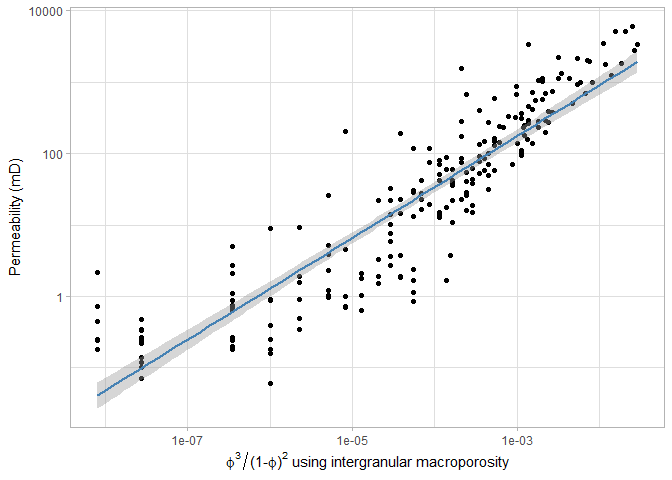

```
##
## Call:
## lm(formula = log(KLH) ~ log(CK_void_fraction), data = df)
##
## Residuals:
##     Min      1Q  Median      3Q     Max
## -3.2600 -0.8124  0.0698  0.7935  3.9761
##
## Coefficients:
##                       Estimate Std. Error t value Pr(>|t|)
## (Intercept)           10.08803    0.24257   41.59   <2e-16 ***
## log(CK_void_fraction)  0.71222    0.02298   30.99   <2e-16 ***
## ---
## Signif. codes:  0 '***' 0.001 '**' 0.01 '*' 0.05 '.' 0.1 ' ' 1
##
## Residual standard error: 1.261 on 213 degrees of freedom
## Multiple R-squared:  0.8185, Adjusted R-squared:  0.8176
## F-statistic: 960.5 on 1 and 213 DF,  p-value: < 2.2e-16
```

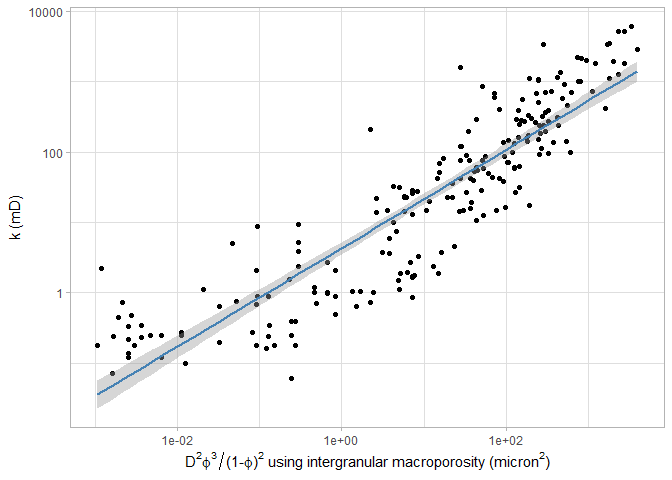

```
##
## Call:
## lm(formula = log(KLH) ~ log(k_pred), data = mutate(df, k_pred = mean_GS^2 *
##     CK_void_fraction))
##
## Residuals:
##     Min      1Q  Median      3Q     Max
## -3.2742 -0.8639  0.0866  0.8664  4.0401
##
## Coefficients:
##             Estimate Std. Error t value Pr(>|t|)
## (Intercept)  1.45598    0.10427   13.96   <2e-16 ***
## log(k_pred)  0.69914    0.02359   29.64   <2e-16 ***
## ---
## Signif. codes:  0 '***' 0.001 '**' 0.01 '*' 0.05 '.' 0.1 ' ' 1
##
## Residual standard error: 1.307 on 213 degrees of freedom
## Multiple R-squared:  0.8048, Adjusted R-squared:  0.8039
## F-statistic: 878.5 on 1 and 213 DF,  p-value: < 2.2e-16
```

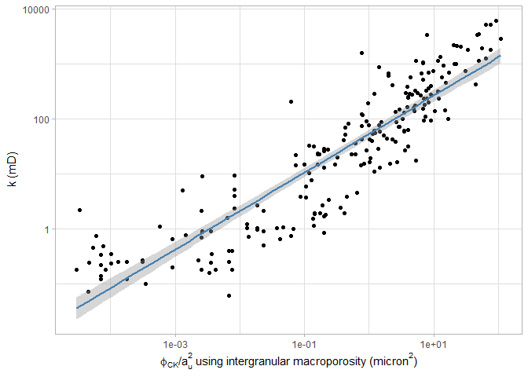

```
##
## Call:
## lm(formula = log(KLH) ~ log(k_pred), data = mutate(df, k_pred = CK_void_fraction/a_u^2))
##
## Residuals:
##     Min      1Q  Median      3Q     Max
## -3.2742 -0.8639  0.0866  0.8664  4.0401
##
## Coefficients:
##             Estimate Std. Error t value Pr(>|t|)
## (Intercept)  3.96136    0.09422   42.05   <2e-16 ***
## log(k_pred)  0.69914    0.02359   29.64   <2e-16 ***
## ---
## Signif. codes:  0 '***' 0.001 '**' 0.01 '*' 0.05 '.' 0.1 ' ' 1
##
## Residual standard error: 1.307 on 213 degrees of freedom
## Multiple R-squared:  0.8048, Adjusted R-squared:  0.8039
## F-statistic: 878.5 on 1 and 213 DF,  p-value: < 2.2e-16
```

Okay, so that’s not helping the regression. It looks like Carman-Kozeny void fraction is our best main predictor.

Maybe adding the uncemented tortuosity will help. Maybe both tortuosity and the specific surface area are needed. Let’s throw it all together, then make a Spearman correlation table as well, for good measure.

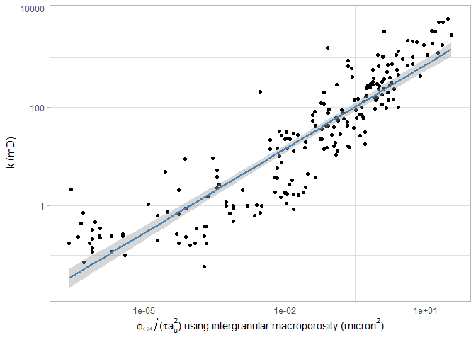

```
##
## Call:
## lm(formula = log(KLH) ~ log(k_pred), data = mutate(df, k_pred = CK_void_fraction/(tau_o *
##     a_u^2)))
##
## Residuals:
##     Min      1Q  Median      3Q     Max
## -3.2216 -0.8336  0.0901  0.7968  4.0756
##
## Coefficients:
##             Estimate Std. Error t value Pr(>|t|)
## (Intercept)   5.2586     0.1138   46.19   <2e-16 ***
## log(k_pred)   0.5662     0.0187   30.28   <2e-16 ***
## ---
## Signif. codes:  0 '***' 0.001 '**' 0.01 '*' 0.05 '.' 0.1 ' ' 1
##
## Residual standard error: 1.285 on 213 degrees of freedom
## Multiple R-squared:  0.8115, Adjusted R-squared:  0.8106
## F-statistic: 916.7 on 1 and 213 DF,  p-value: < 2.2e-16
```

Okay, well, the original (pre-compaction) tortuosity is helping things. Of course, it is a function of porosity, so really we’re just building more complicated models for explaining porosity’s effect on permeability. Also, this isn’t really better than just using the Carman-Kozeny void fraction. With that in mind, let’s look at tortuosity after taking the variable grain sizes into account.

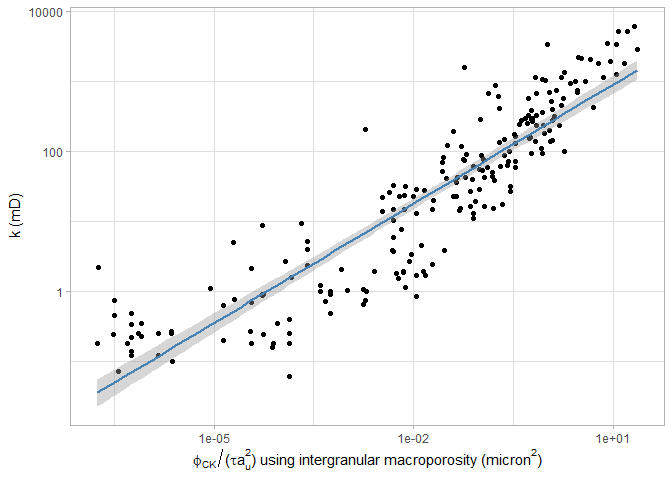

```
##
## Call:
## lm(formula = log(KLH) ~ log(k_pred), data = mutate(df, k_pred = CK_void_fraction/(tau_u *
##     a_u^2)))
##
## Residuals:
##     Min      1Q  Median      3Q     Max
## -3.2422 -0.8158  0.1023  0.8130  4.1139
##
## Coefficients:
##             Estimate Std. Error t value Pr(>|t|)
## (Intercept)   5.4844     0.1179   46.52   <2e-16 ***
## log(k_pred)   0.5676     0.0186   30.52   <2e-16 ***
## ---
## Signif. codes:  0 '***' 0.001 '**' 0.01 '*' 0.05 '.' 0.1 ' ' 1
##
## Residual standard error: 1.277 on 213 degrees of freedom
## Multiple R-squared:  0.8139, Adjusted R-squared:  0.813
## F-statistic: 931.6 on 1 and 213 DF,  p-value: < 2.2e-16
```

And that helps a bit, but it still isn’t as good as just using $\phi_{CK}$. But wait, there’s more! Cementation should matter. Let’s try the cemented measure of tortuosity. That ought to get us somewhere.

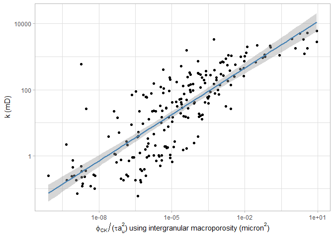

```
##
## Call:
## lm(formula = log(KLH) ~ log(k_pred), data = mutate(df, k_pred = CK_void_fraction/(tau_e *
##     a_u^2)))
##
## Residuals:
##     Min      1Q  Median      3Q     Max
## -4.1900 -1.1330 -0.0377  1.0642  7.5452
##
## Coefficients:
##             Estimate Std. Error t value Pr(>|t|)
## (Intercept)  8.28334    0.27783   29.81   <2e-16 ***
## log(k_pred)  0.46949    0.02267   20.71   <2e-16 ***
## ---
## Signif. codes:  0 '***' 0.001 '**' 0.01 '*' 0.05 '.' 0.1 ' ' 1
##
## Residual standard error: 1.705 on 213 degrees of freedom
## Multiple R-squared:  0.6681, Adjusted R-squared:  0.6665
## F-statistic: 428.7 on 1 and 213 DF,  p-value: < 2.2e-16
```

Oops, switching to effective tortuosity hurts the fit. Okay then, let’s add effective surface area. But how? The effective surface area has fitting parameters that we don’t know a priori — the effects of pore lining, bridging, and filling cement on the specific surface area. So, what do we do? Well, let’s start by looking at cement volume versus permeability. Then, let’s look at the Spearman correlation matrices between these cements and permeability.

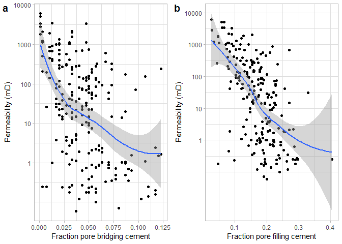

```
##                  CK_void_fraction        P_b        P_f        KLH
## CK_void_fraction        1.0000000 -0.4197979 -0.5868664  0.9308890
## P_b                    -0.4197979  1.0000000  0.1151770 -0.4736764
## P_f                    -0.5868664  0.1151770  1.0000000 -0.6095451
## KLH                     0.9308890 -0.4736764 -0.6095451  1.0000000
```

Ah ha! This matters. Nice, high, Spearman r values showing that pore-filling and pore-bridging cement are bad for permeability. Now, these also happen to be strongly correlated with interparticle porosity and, as one might expect, so the story could be complicated, there. This looks like enough to start setting up a regression. What form should this regression take? Let’s take some inspiration from Winland and slightly abuse Panda and Lake’s (1995) Carman-Kozeny equation.

After that abuse, the regression equation becomes
$$\begin{equation}
\log k = A_1 \log \phi_{CK} - A_2 \log P_b - A_3 \log P_f - A_4 \log a_u - A_5 \log \tau_e + A_0.
\end{equation}$$

Now, to the regressor!

```
##
## Call:
## lm(formula = log(KLH) ~ log(CK_void_fraction) + log(P_b) + log(P_f) +
##     log(a_u) + log(tau_e), data = df, na.action = na.exclude)
##
## Residuals:
##     Min      1Q  Median      3Q     Max
## -3.1513 -0.8064  0.0719  0.7716  3.8951
##
## Coefficients:
##                       Estimate Std. Error t value Pr(>|t|)
## (Intercept)            5.01954    1.07582   4.666 5.49e-06 ***
## log(CK_void_fraction)  0.62982    0.02597  24.255  < 2e-16 ***
## log(P_b)              -0.46819    0.10312  -4.540 9.48e-06 ***
## log(P_f)              -0.77252    0.21598  -3.577 0.000432 ***
## log(a_u)              -0.11392    0.22681  -0.502 0.616002
## log(tau_e)             0.07359    0.03829   1.922 0.055987 .
## ---
## Signif. codes:  0 '***' 0.001 '**' 0.01 '*' 0.05 '.' 0.1 ' ' 1
##
## Residual standard error: 1.157 on 209 degrees of freedom
## Multiple R-squared:  0.8499, Adjusted R-squared:  0.8463
## F-statistic: 236.7 on 5 and 209 DF,  p-value: < 2.2e-16
```

```
##      RMSE  Rsquared       MAE
## 1.1410837 0.8499225 0.8866148
```

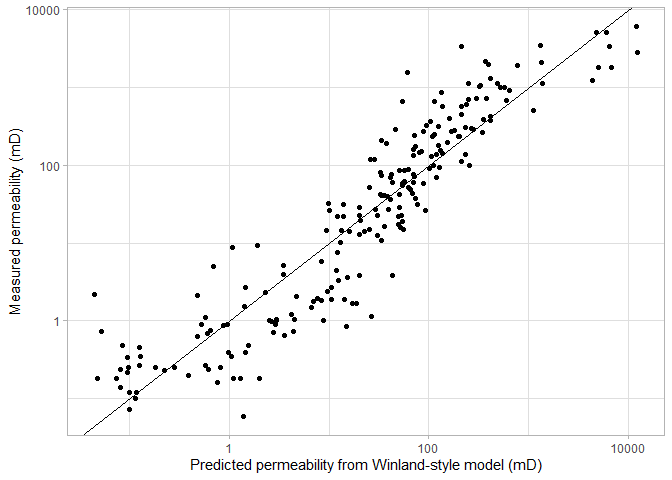

```
## [1] "The predictors are: CK_void_fraction, tau_e, P_f, P_b"
```

This is not a terribly surprising result. Now, to the gradient boosting regressor to see how it all comes together.

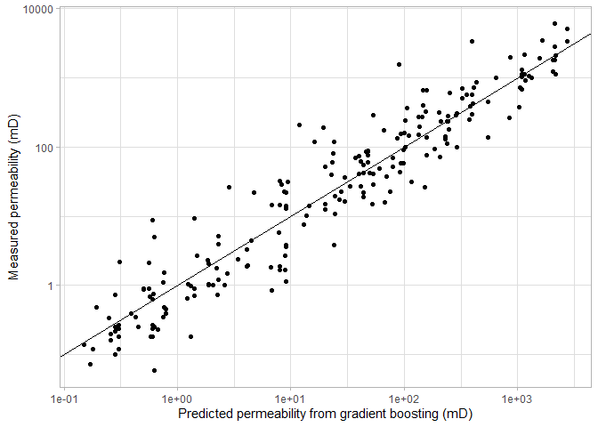

```
##      RMSE  Rsquared       MAE
## 3.3626574 0.7301831 2.9247083
```

```
##      RMSE  Rsquared       MAE
## 5.2617136 0.5800722 4.9913699
```

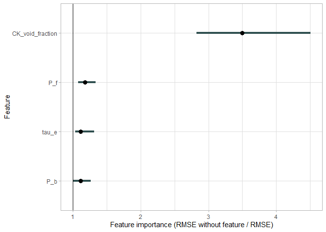

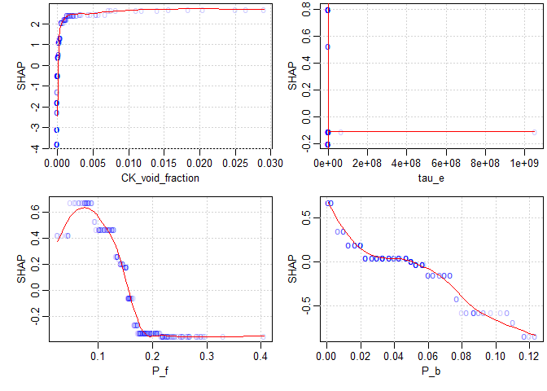

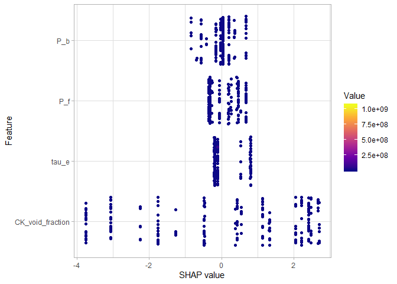

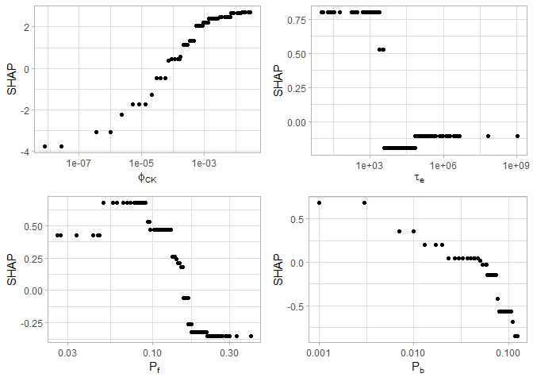

## Appendix A

### Derivation of a modified Carman-Kozeny equation for uncemented sandstones

#### Following Panda and Lake (1994)

We start with the Carman-Kozeny equation
$$\begin{equation}
k = \frac{\phi^3}{2\tau(1-\phi)^2 a^2},
\end{equation}$$

where permeability is $k$, porosity is $\phi$, tortuosity is $\tau$, and the specific surface area is $a$. For porosity, we use the porosity to Helium that has been measured on the Garn data. Permeability is air permeability that has been corrected for Klinkenberg effects. In order to measure tortuosity and specific surface area, we have measurements of the median grain size and Trask sorting coefficient, following the approach proposed by Beard and Weyl (1973). Skewness of the distribution of grain sizes can be extracted from these parameters.

Given this information, a modified Carman Kozeny equation following Panda and Lake (1994) is
$$\begin{equation}
k = \frac{\bar{D}^2 \phi^3}{72\tau_u \left(1-\phi \right)^2} \frac{\left(\gamma C_D^3 + 3C_D^2 +1 \right)^2}{\left(1+C_D^2\right)^2},
\end{equation}$$

where $\bar{D}$ is the mean particle size, $C_D$ is the coefficient of varation of the particle size distribution ($C_D=\sigma_D/\bar{D}$), $\gamma$ is the skewness of the particle size distribution. and $\tau_u$ is the tortuosity of an unconsolidated, uncemented sand.

Panda and Lake (1994) do not calculate the original tortuosity. However, there has been a wealth of work on this problem in the physics, soil, and petroleum literature. One approach is proposed by Ghanbarian, et al. (2013). This approach makes use of percolation theory and results in tortuosity following a power law with respect to porosity. Taking their equation 8 (which assumes reasonably well-sorted grains and a large system) and plugging in the relevant numbers, original tortuosity follows the equation
$$\begin{align}
\tau_o &= \left(\frac{\phi - \phi_t}{1 - \phi_t} \right)^{\nu(1-D)} \\
&= \left(\frac{0.9\phi}{1-0.1\phi} \right)^{-0.378}
\end{align}$$
Panda and Lake (1995) use a surface area argument to derive the effective tortuosity for an uncemented sandstone of different size particles, which is
$$\begin{equation}
\tau_u = \tau_o \left(1 + C_D^2 \right).
\end{equation}$$

Next, let’s look at the distribution of the distribution measures, $\bar D,\ C_D$, and $\gamma$:

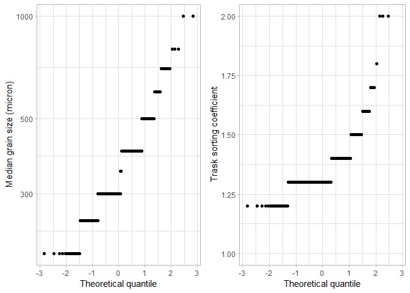

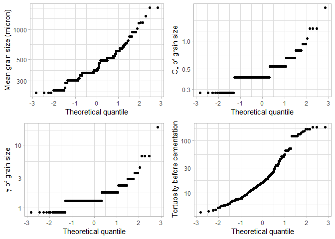

## Appendix B

### Derivation of Carman-Kozeny corrections for cemented sandstones

#### Following Panda and Lake (1995)

Carman-Kozeny theory does not consider the effect of cementation on permeability, but we know that cement is present in these rocks, and that it blocks flow paths, decreasing the permeability. In terms of the quantities considered by Carman and Kozeny, this changes the tortuosity and the specific surface area. There are several different cements that could be present, and they are measured through point counting. The next figure shows the abundance of each cement.

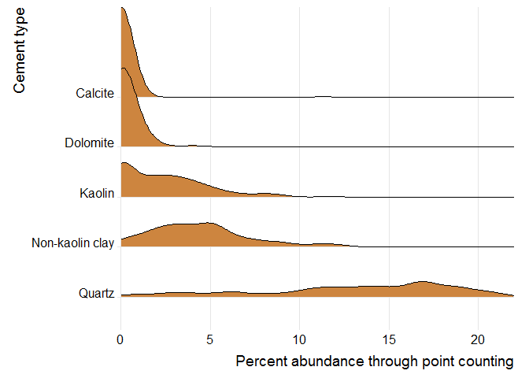

Pore-lining cements find it energetically favorable to form long crystals that stretch out from the grains. These cements include the non-kaolinite clay minerals, such as chlorite, illite, and smectite. The long crystals affect permeability more than they affect porosity because of the large surface areas they generate.

Pore-bridging cements can partially or completely block the pore throats. This strongly influences the permeability, increasing the tortuosity of the system and decreasing the connectivity. Examples of the minerals that bridge pores include illite, chlorite, and montmorillonite (the non-Kaolin clay minerals).

After cementation, the tortuosity and specific surface area has changed. Panda and Lake (1995) suggest an effective tortuosity, $\tau_e$, given by
$$\begin{equation}
\tau_e = \tau_u \left(1+C_D^2 \right)\left(1+\frac{Rm_b}{1-m_b} \right)^2 \left(1 + \frac{2m}{(1-m) \phi^{1/3}} \right)^2,
\end{equation}$$

where $R$ is a constant equal to 2 indicating the additional distance traveled by the fluid as a function of the thickness of cementation. The volume fraction of pore-bridging cement is $m_b = P_b(1-\phi)/\phi$, and the volume fraction of pore-filling cement is $m = P_f (1-\phi)/\phi$.

For an unconsolidated sand of variable sizes, the specific surface area is
$$\begin{equation}
a_u = \frac{6(\sigma^2 + \bar{D}^2)}{\gamma \sigma^3 + 3\bar{D}\sigma^2 + \bar{D}^3}
\end{equation}$$
After cementation, the effective specific surface area follows the equation
$$\begin{equation}
a_e = a_u \frac{1-\phi_u}{1-\phi} + a_b P_b + a_f P_f
\end{equation}$$

where $a_u$ is the specific surface area for an unconsolidated, uncemented sand, $\phi_u$ is the porosity of an unconsolidated sand, $a_b$ is the specific surface area for a pore-bridging cement, $a_f$ is the specific surface area for a pore-filling cement, and $P_b,P_f$ are the relative fractions of pore-bridging and pore-filling cement, respectively.

Taking these equations together, the equation for permeability becomes
$$\begin{equation}
k = \left[\bar{D}^2 \phi^3 \left(\gamma C_D^3 + 3C_D^2 + 1 \right)^2 \right]
\left\{ 2\tau_e (1-\phi)^2 \left[ 6\left(1+C_D^2 \right) \frac{1-\phi_u}{1-\phi} +
\left(a_b P_b + a_f P_f \right) \bar{D} \left(\gamma C_D^3 + 3C_D^2 +1 \right) \right]^2\right\}^{-1}
\end{equation}$$

Now, with these calculations, the properties of the grain size distribution measured by Ehrenberg (1990) can be used to test the theory derived by Panda and Lake (1995).

## Appendix C

### Lognormal distribution statistics

Grain size distribution is often described by the median grain size and the Trask Sorting Coefficient ($S_o$), which is defined by $S_o=\sqrt{D_{0.75}/D_{0.25}}$, where $D_p$ is the quantile value indicated by $p$, such that $D_{0.25}$ is the 25%-ile grain size. Panda (1994, Appendix B) derived an equation relating average grain size, Trask Sorting Coefficient, and the standard deviation of the grain size, which is
$$\begin{equation}
\sigma = \bar{D} \frac{S_o^2-1}{0.675\left(S_o^2+1\right)}.
\end{equation}$$

This equation is done through $D_p$ being calculated in a $\log_2$ space, but most calculations of $S_o$ use the definition I provided above, so this should be re-derived.

According to my derivation, assuming lognormality, following a distribution with the PDF
$$\begin{equation}
\frac{1}{x\sigma\sqrt{2\pi}} \exp\left(-\frac{(\ln x-\mu)^2}{2\sigma^2} \right),
\end{equation}$$
the mean grain size is $\bar{D} = \exp(\mu + \sigma/2)$, and in terms of the median and Trask sorting coefficient, the parameters of the distribution are
$$\begin{align}
\mu &= \ln D_{0.5}\\
\sigma &= \frac{\ln S_o}{\sqrt{2}\ \text{erf}^{-1}(0.5)}
\end{align}$$

Okay, let’s test those stats with a randomly generated lognormal distribution:

```r
mu <- 3.14159
sigma <- 1
d <- rlnorm(10000, mu, sigma) # distribution of 1k points with mu=10, sigma=1

trask <- sqrt(quantile(d,0.75) / quantile(d,0.25))
d_50 <- median(d)
mu_calc <- log(d_50)
erfinv <- function(x) qnorm((x + 1)/2)/sqrt(2)
sigma_calc <- log(trask) / (sqrt(2) * erfinv(0.5))
mean_calc <- exp(log(d_50) + sigma_calc/2)
exponent_thingie <- (2*sqrt(2) * erfinv(0.5))

cat(
  "\nThe median is", round(median(d),1),
       "It should be", round(exp(mu),1),
      "\nThe mean is",round(mean(d),1),
      "It should be", round(exp(mu + sigma/2),1),
      "\nThe standard deviation is",round(sd(d),1),
      "It should be",round( sqrt( (exp(sigma^2)-1) * exp(2*mu+sigma^2))),
      "\nThe Trask sorting coefficient is",round(sqrt(quantile(d,0.75) / quantile(d,0.25)),2),
  "\nFrom the Trask and median diameters, the mean should be", round(mean_calc,1),"or",
  round(d_50 * trask^(1/(2*sqrt(2) * erfinv(0.5))),1),
  "\nThis is a deviation of", round((exp(mu + sigma/2) - mean_calc)/exp(mu + sigma/2)*100,1),"percent\n"

)
```

```
##
## The median is 23.4 It should be 23.1
## The mean is 37.8 It should be 38.2
## The standard deviation is 48.2 It should be 50
## The Trask sorting coefficient is 1.95
## From the Trask and median diameters, the mean should be 38.4 or 38.4
## This is a deviation of -0.6 percent
```

# ETC

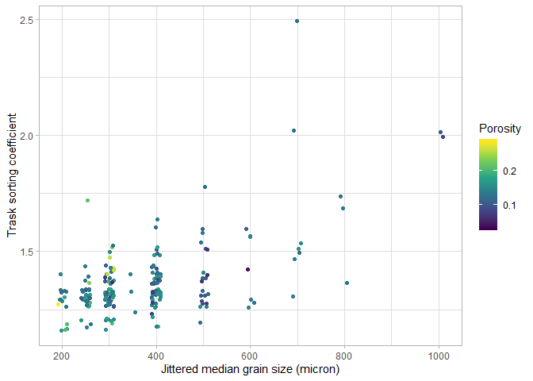

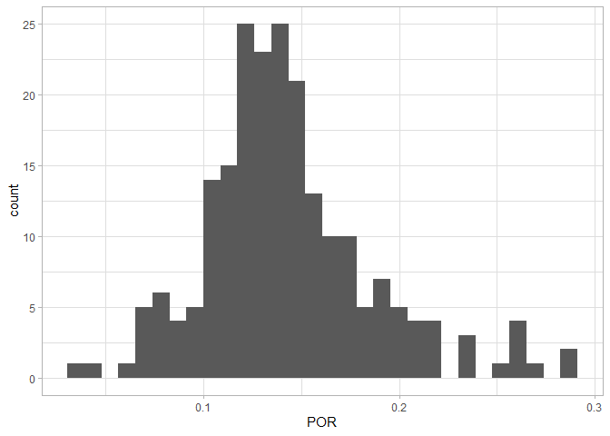

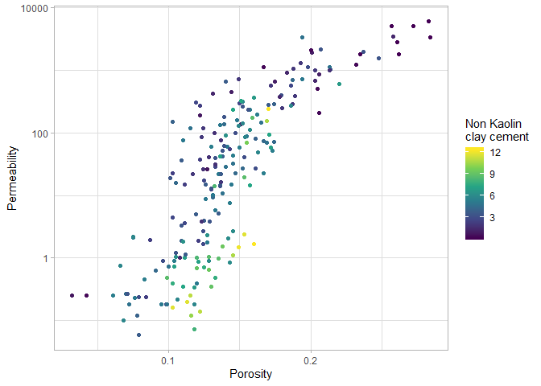

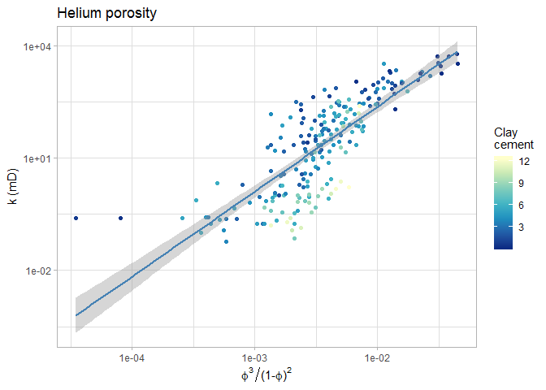

```
##
## Call:
## lm(formula = KLH ~ POR^3/(1 - POR)^2, data = df)
##
## Residuals:
##     Min      1Q  Median      3Q     Max
## -1030.6  -321.9  -128.0   191.1  3731.1
##
## Coefficients:
##             Estimate Std. Error t value Pr(>|t|)
## (Intercept)  -1688.4      138.1  -12.22   <2e-16 ***
## POR          14199.0      926.1   15.33   <2e-16 ***
## ---
## Signif. codes:  0 '***' 0.001 '**' 0.01 '*' 0.05 '.' 0.1 ' ' 1
##
## Residual standard error: 584.6 on 213 degrees of freedom
## Multiple R-squared:  0.5246, Adjusted R-squared:  0.5224
## F-statistic: 235.1 on 1 and 213 DF,  p-value: < 2.2e-16
```

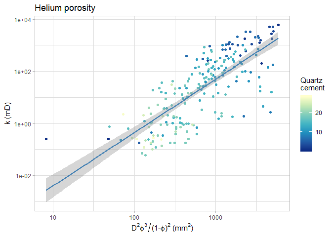

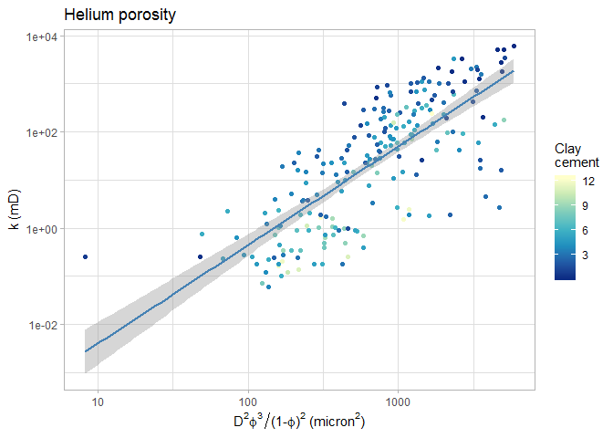

```
##
## Call:
## lm(formula = KLH ~ mean_GS^2 * POR^3/(1 - POR)^2, data = df)
##
## Residuals:
##    Min     1Q Median     3Q    Max
## -924.9 -304.3  -95.5  196.4 3599.4
##
## Coefficients:
##               Estimate Std. Error t value Pr(>|t|)
## (Intercept) -2816.2781   364.1172  -7.735 4.20e-13 ***
## mean_GS         2.5475     0.7786   3.272  0.00125 **
## POR         22182.4838  2701.3698   8.212 2.16e-14 ***
## mean_GS:POR   -18.6961     6.2068  -3.012  0.00291 **
## ---
## Signif. codes:  0 '***' 0.001 '**' 0.01 '*' 0.05 '.' 0.1 ' ' 1
##
## Residual standard error: 572.4 on 211 degrees of freedom
## Multiple R-squared:  0.5486, Adjusted R-squared:  0.5422
## F-statistic: 85.49 on 3 and 211 DF,  p-value: < 2.2e-16
```

```
##
## Call:
## lm(formula = KLH ~ GS^2 * POR^3/(1 - POR)^2, data = df)
##
## Residuals:
##    Min     1Q Median     3Q    Max
## -950.1 -292.3  -78.4  175.1 3591.9
##
## Coefficients:
##              Estimate Std. Error t value Pr(>|t|)
## (Intercept) -3282.395    428.431  -7.661 6.57e-13 ***
## GS              4.512      1.167   3.865 0.000148 ***
## POR         25144.664   3090.141   8.137 3.46e-14 ***
## GS:POR        -32.015      8.960  -3.573 0.000437 ***
## ---
## Signif. codes:  0 '***' 0.001 '**' 0.01 '*' 0.05 '.' 0.1 ' ' 1
##
## Residual standard error: 567 on 211 degrees of freedom
## Multiple R-squared:  0.557,  Adjusted R-squared:  0.5507
## F-statistic: 88.43 on 3 and 211 DF,  p-value: < 2.2e-16
```

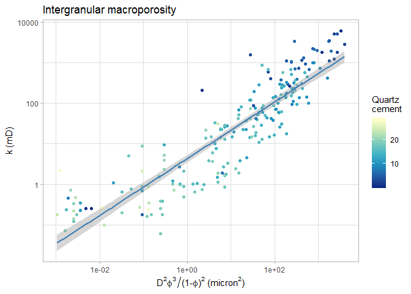

```
##
## Call:
## lm(formula = KLH ~ IMP^3/(1 - IMP)^2, data = mutate(df, IMP = IMP/100))
##
## Residuals:
##    Min     1Q Median     3Q    Max
## -896.7 -320.2  -11.7  258.0 3582.9
##
## Coefficients:
##             Estimate Std. Error t value Pr(>|t|)
## (Intercept)  -375.27      56.98  -6.586 3.48e-10 ***
## IMP         11742.47     699.04  16.798  < 2e-16 ***
## ---
## Signif. codes:  0 '***' 0.001 '**' 0.01 '*' 0.05 '.' 0.1 ' ' 1
##
## Residual standard error: 556.1 on 213 degrees of freedom
## Multiple R-squared:  0.5698, Adjusted R-squared:  0.5678
## F-statistic: 282.2 on 1 and 213 DF,  p-value: < 2.2e-16
```

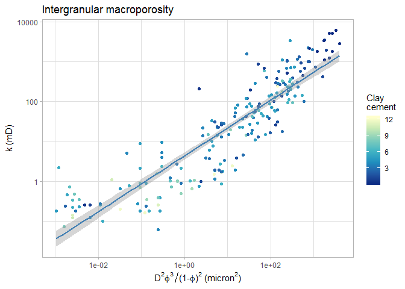

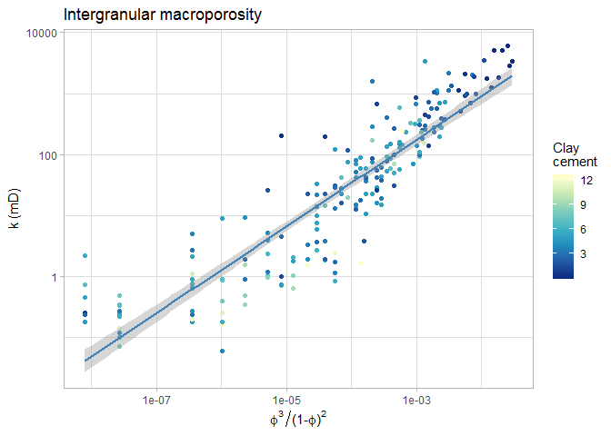

```
##
## Call:
## lm(formula = KLH ~ mean_GS^2 * IMP^3/(1 - IMP)^2, data = mutate(df,
##     IMP = IMP/100))
##
## Residuals:
##     Min      1Q  Median      3Q     Max
## -1092.5  -277.2   -15.1   227.9  3510.4
##
## Coefficients:
##               Estimate Std. Error t value Pr(>|t|)
## (Intercept)  -504.0130   126.0618  -3.998 8.83e-05 ***
## mean_GS         0.3472     0.2499   1.390   0.1661
## IMP         16023.1146  2002.5738   8.001 8.09e-14 ***
## mean_GS:IMP   -10.9041     4.7369  -2.302   0.0223 *
## ---
## Signif. codes:  0 '***' 0.001 '**' 0.01 '*' 0.05 '.' 0.1 ' ' 1
##
## Residual standard error: 551.7 on 211 degrees of freedom
## Multiple R-squared:  0.5807, Adjusted R-squared:  0.5747
## F-statistic:  97.4 on 3 and 211 DF,  p-value: < 2.2e-16
```

```
##
## Call:
## lm(formula = KLH ~ GS^2 * IMP^3/(1 - IMP)^2, data = mutate(df,
##     IMP = IMP/100))
##
## Residuals:
##     Min      1Q  Median      3Q     Max
## -1081.6  -274.5    -5.4   217.5  3535.0
##
## Coefficients:
##               Estimate Std. Error t value Pr(>|t|)
## (Intercept)  -531.8282   156.7496  -3.393 0.000826 ***
## GS              0.5262     0.4137   1.272 0.204739
## IMP         16535.3395  2263.9842   7.304 5.65e-12 ***
## GS:IMP        -15.3380     6.8062  -2.254 0.025252 *
## ---
## Signif. codes:  0 '***' 0.001 '**' 0.01 '*' 0.05 '.' 0.1 ' ' 1
##
## Residual standard error: 551.7 on 211 degrees of freedom
## Multiple R-squared:  0.5807, Adjusted R-squared:  0.5747
## F-statistic: 97.41 on 3 and 211 DF,  p-value: < 2.2e-16
```